# R for Data Science

## 2.6 Inner Join

The output of an inner join is a new data frame that contains the key, the x values, and the y values.

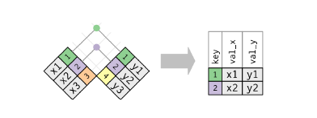

```r
x %>%
  inner_join(y, by = "key")
```

```
## # A tibble: 2 x 3
##     key val_x val_y
##   <dbl> <chr> <chr>
## 1     1 x1    y1
## 2     2 x2    y2
```

가장 중요한 특성은 매치되지 않은 행은 결과에 포함이 되지 않는다는 것. 하지만 일반적으로 관측치를 잃기 때문에 분석에서 적절하지는 않다.

## 2.7 Outer Joins

- Left join
- Right join
- Full join

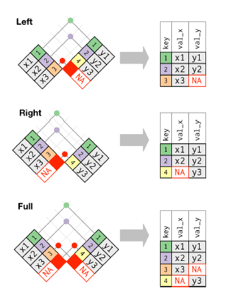

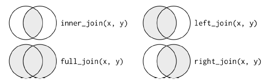

## 2.8 Duplicate Keys

지금까지는 key가 유일한 경우만 다루었지만 실제로는 아닐 수 있다.

- 하나의 테이블이 복제 key를 가질 수 있다. one-to-many 관계가 있을 때 정보를 추가하는 데에 유용하다.

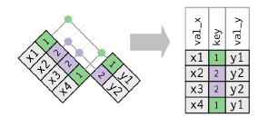

```r
x <- tribble(
  ~key, ~val_x,
  1, "x1",
  2, "x2",
  2, "x3",
  1, "x4"
)
y <- tribble(
  ~key, ~val_y,
  1, "y1",
  2, "y2"
)
left_join(x, y, by = "key")
```

```
## # A tibble: 4 x 3
##     key val_x val_y
##   <dbl> <chr> <chr>
## 1     1 x1    y1
## 2     2 x2    y2
## 3     2 x3    y2
## 4     1 x4    y1
```

- 두 테이블 모두 복제 키를 가질 수 있다. 이것은 관측치를 유일하게 식별할 수 없어서 보통 에러다. 복제 키를 join할 때, 모든 가능한 조합을 가진다. 즉, Cartesian product(= 외적)

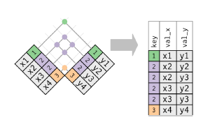

```r
x <- tribble(
  ~key, ~val_x,
  1, "x1",
  2, "x2",
  2, "x3",
  3, "x4"
)
y <- tribble(
  ~key, ~val_y,
  1, "y1",
  2, "y2",
  2, "y3",
  3, "y4"
)
left_join(x, y, by = "key")
```

```
## # A tibble: 6 x 3
##     key val_x val_y
##   <dbl> <chr> <chr>
## 1     1 x1    y1
## 2     2 x2    y2
## 3     2 x2    y3
## 4     2 x3    y2
## 5     2 x3    y3
## 6     3 x4    y4
```

## 2.9 Defining the Key Columns

지금까지, 테이블 쌍은 항상 단 하나의 변수에 의해서 join되었고, 양쪽 테이블의 변수의 이름이 같았다. 다른 방법으로 테이블을 `by`로 연결시킬 수 있다.

- 디폴트 `by = NULL`는 양쪽 테이블의 모든 변수를 사용한다(natural join). 예를 들어, flights and weather 테이블은 공통의 변수를 매칭시킨다 : year, month, day, hour, and origin

```r
flights2 %>%
  left_join(weather)
```

```
## # A tibble: 336,776 x 18
##     year month   day  hour origin dest  tailnum carrier  temp  dewp humid
##    <dbl> <dbl> <int> <dbl> <chr>  <chr> <chr>   <chr>   <dbl> <dbl> <dbl>
##  1  2013     1     1     5 EWR    IAH   N14228  UA       39.0  28.0  64.4
##  2  2013     1     1     5 LGA    IAH   N24211  UA       39.9  25.0  54.8
##  3  2013     1     1     5 JFK    MIA   N619AA  AA       39.0  27.0  61.6
##  4  2013     1     1     5 JFK    BQN   N804JB  B6       39.0  27.0  61.6
##  5  2013     1     1     6 LGA    ATL   N668DN  DL       39.9  25.0  54.8
##  6  2013     1     1     5 EWR    ORD   N39463  UA       39.0  28.0  64.4
##  7  2013     1     1     6 EWR    FLL   N516JB  B6       37.9  28.0  67.2
##  8  2013     1     1     6 LGA    IAD   N829AS  EV       39.9  25.0  54.8
##  9  2013     1     1     6 JFK    MCO   N593JB  B6       37.9  27.0  64.3
## 10  2013     1     1     6 LGA    ORD   N3ALAA  AA       39.9  25.0  54.8
## # ... with 336,766 more rows, and 7 more variables: wind_dir <dbl>,
## #   wind_speed <dbl>, wind_gust <dbl>, precip <dbl>, pressure <dbl>,
## #   visib <dbl>, time_hour <dttm>
```

(flights2에서 time_hour을 제거하면 책과 같은 결과)

- 문자 벡터, `by = "x"`. natural join처럼, 공통된 변수를 사용한다. 예를 들어, flights와 planes은 year 변수를 가지지만 다른 의미를 가지므로 tailnum으로 조인 하겠다.

```r
flights2 %>%
  left_join(planes, by = "tailnum")
```

```
## # A tibble: 336,776 x 16
##    year.x month   day  hour origin dest  tailnum carrier year.y type
##     <int> <int> <int> <dbl> <chr>  <chr> <chr>   <chr>    <int> <chr>
##  1   2013     1     1     5 EWR    IAH   N14228  UA        1999 Fixe~
##  2   2013     1     1     5 LGA    IAH   N24211  UA        1998 Fixe~
##  3   2013     1     1     5 JFK    MIA   N619AA  AA        1990 Fixe~
##  4   2013     1     1     5 JFK    BQN   N804JB  B6        2012 Fixe~
##  5   2013     1     1     6 LGA    ATL   N668DN  DL        1991 Fixe~
##  6   2013     1     1     5 EWR    ORD   N39463  UA        2012 Fixe~
##  7   2013     1     1     6 EWR    FLL   N516JB  B6        2000 Fixe~
##  8   2013     1     1     6 LGA    IAD   N829AS  EV        1998 Fixe~
##  9   2013     1     1     6 JFK    MCO   N593JB  B6        2004 Fixe~
## 10   2013     1     1     6 LGA    ORD   N3ALAA  AA          NA <NA>
## # ... with 336,766 more rows, and 6 more variables: manufacturer <chr>,
## #   model <chr>, engines <int>, seats <int>, speed <int>, engine <chr>
```

애매모호함을 피하기 위해 year에 접두사를 붙임.

- `by = c("a" = "b")` 테이블 x의 a와 테이블 y의 b를 매치 시킨다. 예를 들어, 지도를 그리기 위해 flights와 airport를 결합시키고 위치(lat, long)을 포함한다. 각 항공편은 origin과 destination airport를 가지므로 join하고자하는 것을 명시해 줘야 한다.

```r
flights2 %>%
  left_join(airports, c("dest" = "faa"))
```

```
## # A tibble: 336,776 x 15
##     year month   day  hour origin dest  tailnum carrier name    lat   lon
##    <int> <int> <int> <dbl> <chr>  <chr> <chr>   <chr>   <chr> <dbl> <dbl>
##  1  2013     1     1     5 EWR    IAH   N14228  UA      Geor~  30.0 -95.3
##  2  2013     1     1     5 LGA    IAH   N24211  UA      Geor~  30.0 -95.3
##  3  2013     1     1     5 JFK    MIA   N619AA  AA      Miam~  25.8 -80.3
##  4  2013     1     1     5 JFK    BQN   N804JB  B6      <NA>   NA    NA
##  5  2013     1     1     6 LGA    ATL   N668DN  DL      Hart~  33.6 -84.4
##  6  2013     1     1     5 EWR    ORD   N39463  UA      Chic~  42.0 -87.9
##  7  2013     1     1     6 EWR    FLL   N516JB  B6      Fort~  26.1 -80.2
##  8  2013     1     1     6 LGA    IAD   N829AS  EV      Wash~  38.9 -77.5
##  9  2013     1     1     6 JFK    MCO   N593JB  B6      Orla~  28.4 -81.3
## 10  2013     1     1     6 LGA    ORD   N3ALAA  AA      Chic~  42.0 -87.9
## # ... with 336,766 more rows, and 4 more variables: alt <int>, tz <dbl>,
## #   dst <chr>, tzone <chr>
```

```r
flights2 %>%
  left_join(airports, by = c("origin" = "faa"))
```

```
## # A tibble: 336,776 x 15
##     year month   day  hour origin dest  tailnum carrier name    lat   lon
##    <int> <int> <int> <dbl> <chr>  <chr> <chr>   <chr>   <chr> <dbl> <dbl>
##  1  2013     1     1     5 EWR    IAH   N14228  UA      Newa~  40.7 -74.2
##  2  2013     1     1     5 LGA    IAH   N24211  UA      La G~  40.8 -73.9
##  3  2013     1     1     5 JFK    MIA   N619AA  AA      John~  40.6 -73.8
##  4  2013     1     1     5 JFK    BQN   N804JB  B6      John~  40.6 -73.8
##  5  2013     1     1     6 LGA    ATL   N668DN  DL      La G~  40.8 -73.9
##  6  2013     1     1     5 EWR    ORD   N39463  UA      Newa~  40.7 -74.2
##  7  2013     1     1     6 EWR    FLL   N516JB  B6      Newa~  40.7 -74.2
##  8  2013     1     1     6 LGA    IAD   N829AS  EV      La G~  40.8 -73.9
##  9  2013     1     1     6 JFK    MCO   N593JB  B6      John~  40.6 -73.8
## 10  2013     1     1     6 LGA    ORD   N3ALAA  AA      La G~  40.8 -73.9
## # ... with 336,766 more rows, and 4 more variables: alt <int>, tz <dbl>,
## #   dst <chr>, tzone <chr>
```

## 2.10 Exercises

1. Compute the average delay by destination, then join on the air ports data frame so you can show the spatial distribution of delays. Here’s an easy way to draw a map of the United States:

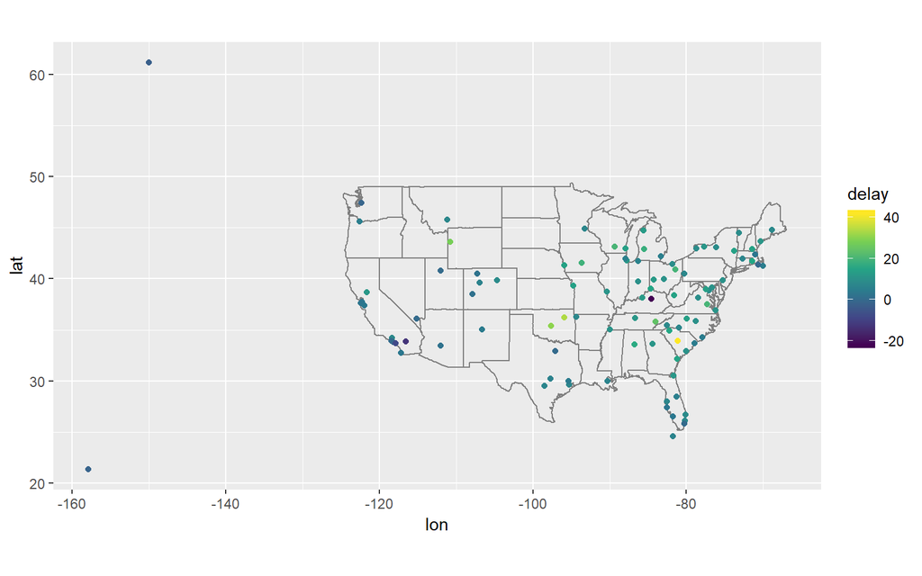

```r
avg_dest_delays <-
  flights %>%
  group_by(dest) %>%
  # arrival delay NA's are cancelled flights
  summarise(delay = mean(arr_delay, na.rm = TRUE)) %>%
  left_join(airports, by = c(dest = "faa"))
# inner_join()을 사용해도 같은 결과

avg_dest_delays %>%
  ggplot(aes(lon, lat, color = delay)) +
    scale_color_viridis_c() +
    borders("state") +
    geom_point() +
    coord_quickmap()
```

2. Add the location of the origin and destination (i.e., the lat and lon) to flights.

```r
flights %>%
  left_join(airports, by = c("dest" = "faa")) %>%
  left_join(airports, by = c("origin" = "faa"), suffix = c(".dest",
".origin")) %>%
  select(dest, origin, contains("lat"), contains("lon"))
```

```
## # A tibble: 336,776 x 6
##    dest  origin lat.dest lat.origin lon.dest lon.origin
##    <chr> <chr>     <dbl>      <dbl>    <dbl>      <dbl>
##  1 IAH   EWR        30.0       40.7    -95.3      -74.2
##  2 IAH   LGA        30.0       40.8    -95.3      -73.9
##  3 MIA   JFK        25.8       40.6    -80.3      -73.8
##  4 BQN   JFK        NA         40.6     NA        -73.8
##  5 ATL   LGA        33.6       40.8    -84.4      -73.9
##  6 ORD   EWR        42.0       40.7    -87.9      -74.2
##  7 FLL   EWR        26.1       40.7    -80.2      -74.2
##  8 IAD   LGA        38.9       40.8    -77.5      -73.9
##  9 MCO   JFK        28.4       40.6    -81.3      -73.8
## 10 ORD   LGA        42.0       40.8    -87.9      -73.9
## # ... with 336,766 more rows
```

중요!! 3. Is there a relationship between the age of a plane and its delays?

내 생각에 아래 풀이는 틀렸다. 비행기의 제조년도별로 평균을 구해버리면 비행기의 사양이 섞여져 버리기 때문이다. 또한 제작년도별로 만들어진 비행기 수의 차이를 포함하지 않는다.

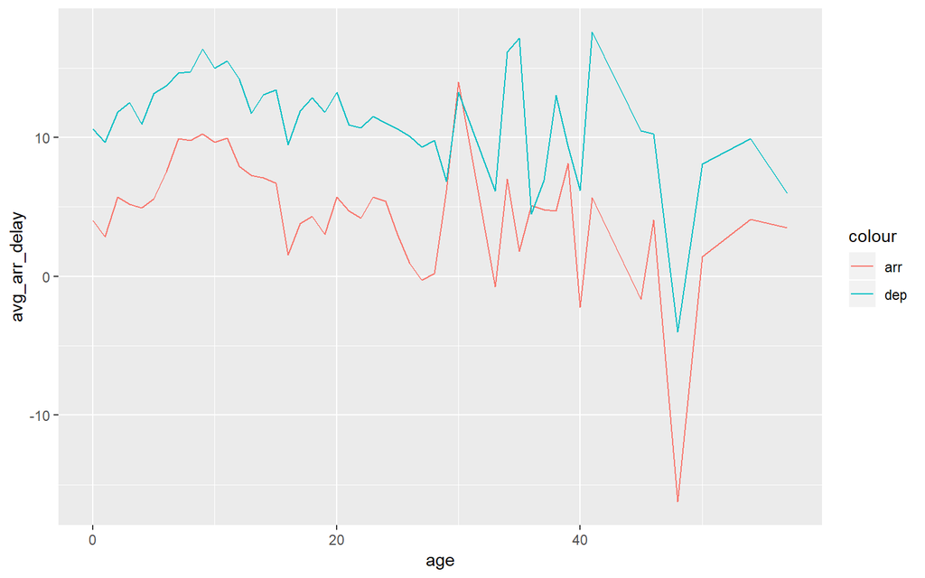

```r
flights %>%
  left_join(planes, by = "tailnum") %>%
  group_by(year.y) %>%
  summarise(
    avg_arr_delay = mean(arr_delay, na.rm = TRUE),
    avg_dep_delay = mean(dep_delay, na.rm = TRUE)
            ) %>%
  select(1:3) %>%
  ggplot(aes(2013 - year.y)) +
    geom_line(aes(y = avg_arr_delay, color = "arr")) +
    geom_line(aes(y = avg_dep_delay, color = "dep")) +
    xlab("age")
```

아래처럼 비행기별로 평균을 구하고 이 비행기의 제조년도를 확인하는 것이 맞는것 같다.

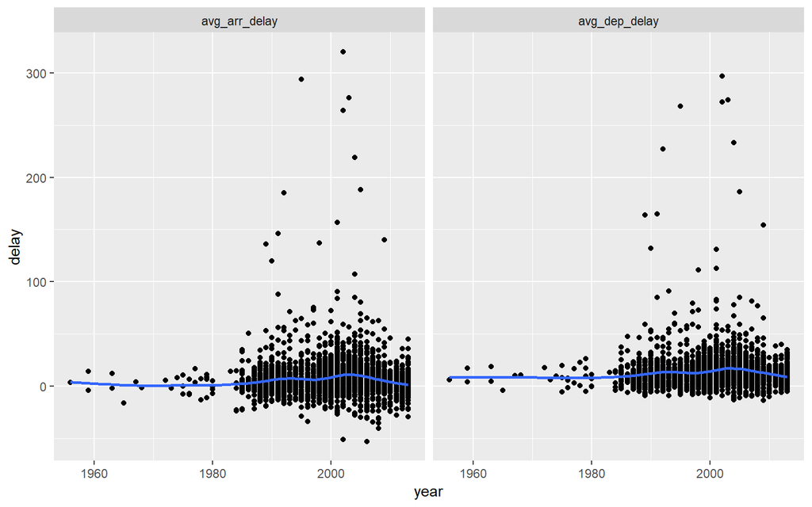

```r
flights %>% group_by(tailnum) %>%
  summarise(avg_dep_delay = mean(dep_delay, na.rm = TRUE),
            avg_arr_delay = mean(arr_delay, na.rm = TRUE)) %>%
  gather(key = 'mode', value = 'delay', 2:3) %>%
  left_join(planes, by = 'tailnum') %>%
  ggplot(mapping = aes(x = year, y = delay)) +
  geom_point() +
  geom_smooth(se = FALSE) +
  facet_grid(.~mode)
```

4. What weather conditions make it more likely to see a delay?

시간을 무시하고 그림을 그렸기 때문에 잘못됐다.

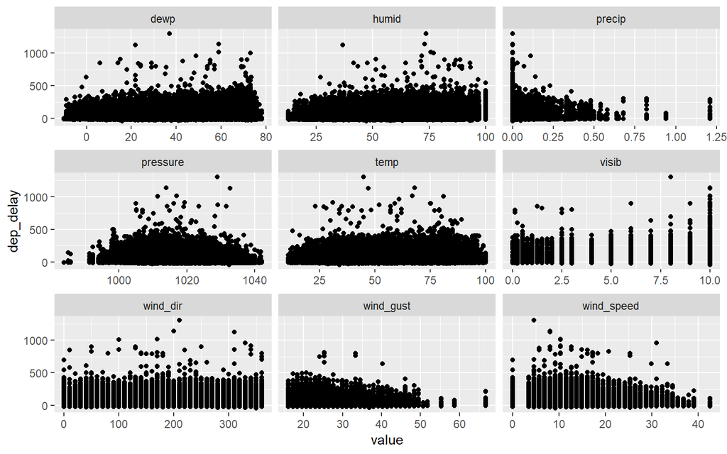

```r
flights %>%
  left_join(weather, by = c('year','month','day','hour','origin')) %>%
  gather(key = 'condition', value = 'value', temp:visib) %>%
  filter(!is.na(dep_delay)) %>%
  ggplot(mapping = aes(x = value, y = dep_delay)) +
  geom_point() +
  facet_wrap(~condition, ncol = 3, scale = 'free_x')
```

강수량을 그룹화 한다..?

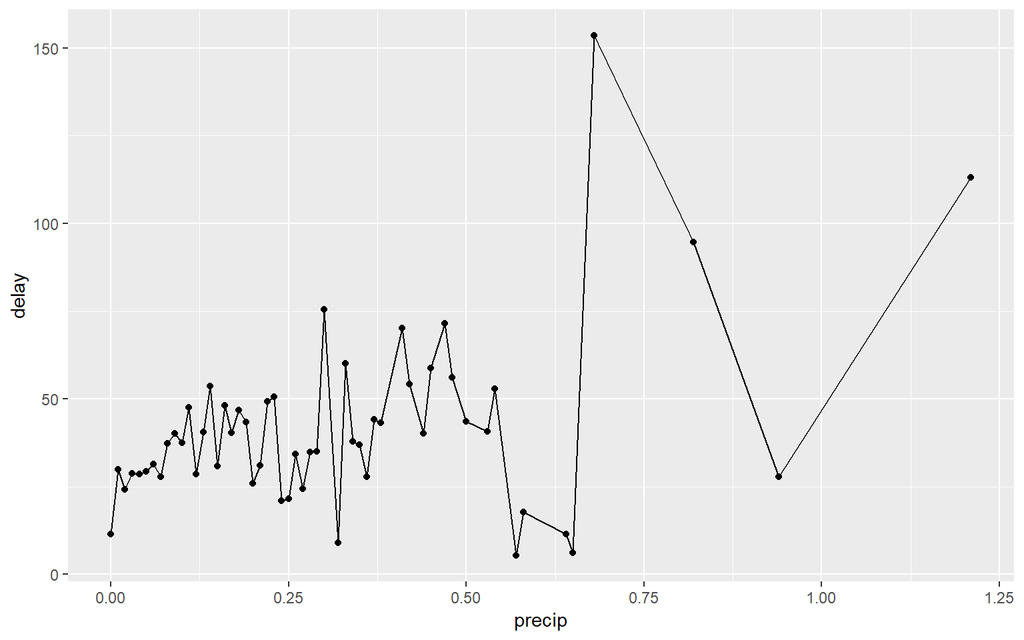

```r
flight_weather <-
  flights %>%
  inner_join(weather, by = c("origin" = "origin",
                            "year" = "year",
                            "month" = "month",
                            "day" = "day",
                            "hour" = "hour"))

flight_weather %>%
  group_by(precip) %>%
  summarise(delay = mean(dep_delay, na.rm = TRUE)) %>%
  ggplot(aes(x = precip, y = delay)) +
    geom_line() + geom_point()
```

시간단위는 불확실성이 너무 커지므로 제외.

```r
avg_del <-
  flights %>%
  mutate(tot_delay = arr_delay + dep_delay) %>%
  group_by(month, day) %>%
  summarize(avg_delay = mean(tot_delay, na.rm = TRUE))

avg_weather <-
  weather %>%
  group_by(month, day) %>%
  select(-hour) %>%
  summarize_at(vars(temp, humid, wind_speed, precip), mean, na.rm = TRUE)
```

왜 x축에 delay를 뒀는지는 모르겠다.

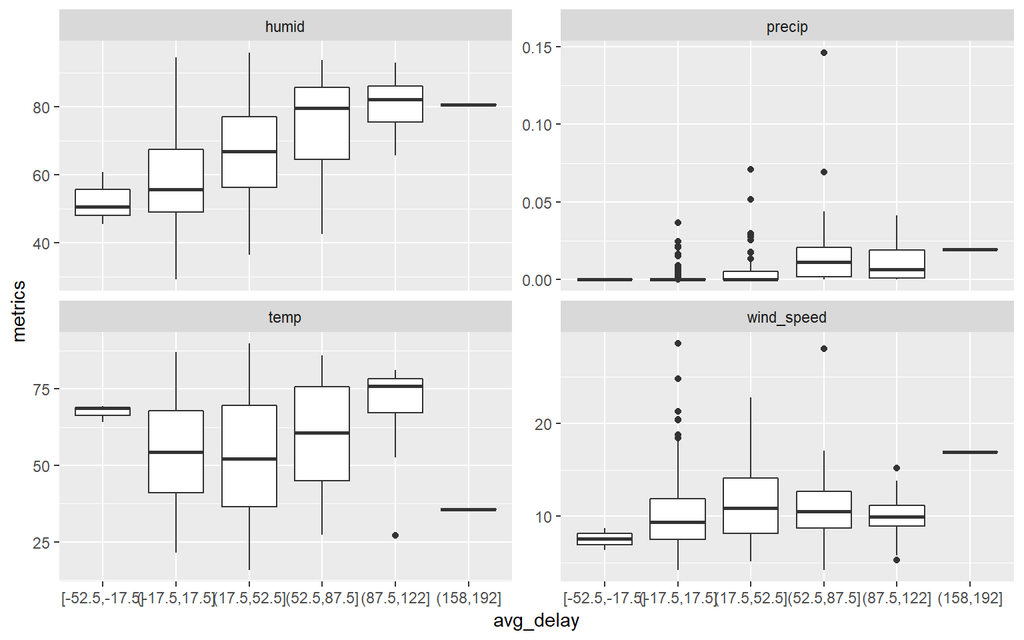

```r
# 상자 그림
avg_del %>%
  left_join(avg_weather) %>%
  ungroup() %>%
  mutate(avg_delay = cut_width(avg_delay, 35)) %>%
  gather(weather, metrics, -(month:avg_delay)) %>%
  ggplot(aes(avg_delay, metrics)) +
  geom_boxplot() +
  facet_wrap(~ weather, scales = "free_y")
```

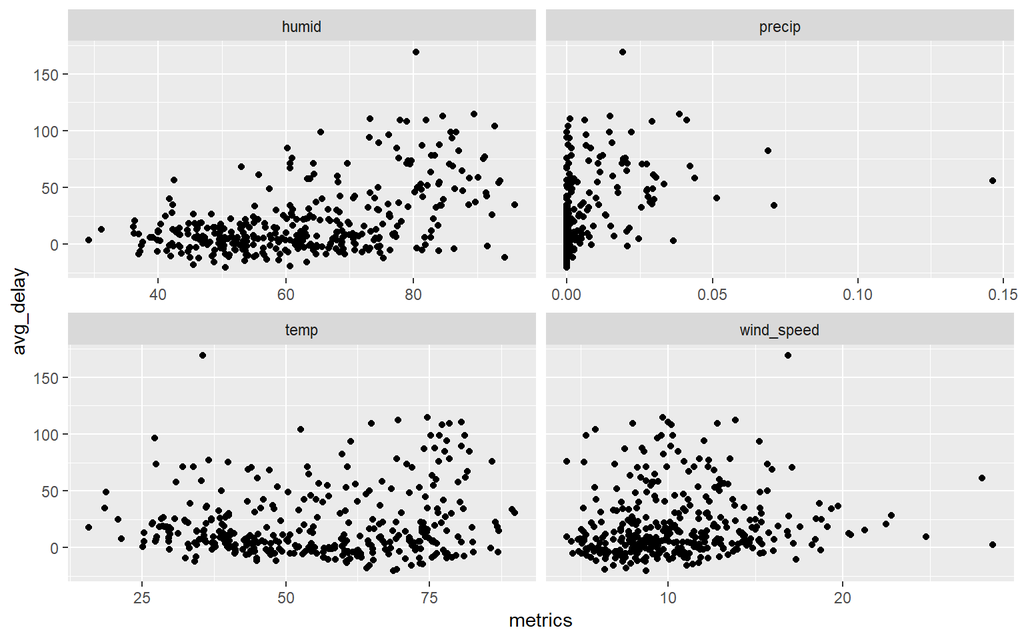

```r
# 산점도
avg_del %>%
  left_join(avg_weather) %>%
  ungroup() %>%
  gather(weather, metrics, -(month:avg_delay)) %>%
  ggplot(aes(metrics, avg_delay)) +
  geom_point() +
  #geom_smooth(method = "lm", se = FALSE) +
  facet_wrap(~ weather, scales = "free_x")
```

delay가 아니라 아예 결항될 가능성도 있다.

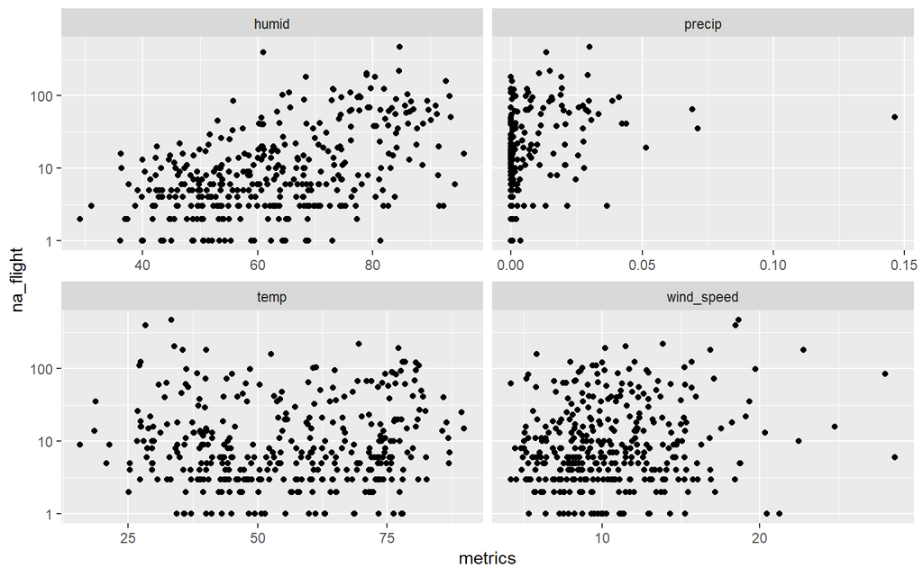

```r
cnt_na <-
  flights %>%
  group_by(month, day) %>%
  summarize(na_flight = sum(is.na(dep_delay)))

avg_weather <-
  weather %>%
  group_by(month, day) %>%
  select(-hour) %>%
  summarize_at(vars(temp, humid, wind_speed, precip), mean, na.rm = TRUE)

cnt_na %>%
  left_join(avg_weather) %>%
  ungroup() %>%
  filter(na_flight > 0) %>%
  gather(weather, metrics, -(month:na_flight)) %>%
  ggplot(aes(metrics, na_flight)) +
  geom_point() +
  facet_wrap(~ weather, scales = "free_x") +
  scale_y_log10()
```

로그를 취하기 전에는 특별한 관계가 없어보였지만 로그를 취하니 습도가 가장 상관관계가 커 보이고 나머지는 특별히 관계가 없어 보인다.

5. What happened on June 13, 2013? Display the spatial pattern of delays, and then use Google to cross-reference with the weather.

이날 태풍이 있었다.

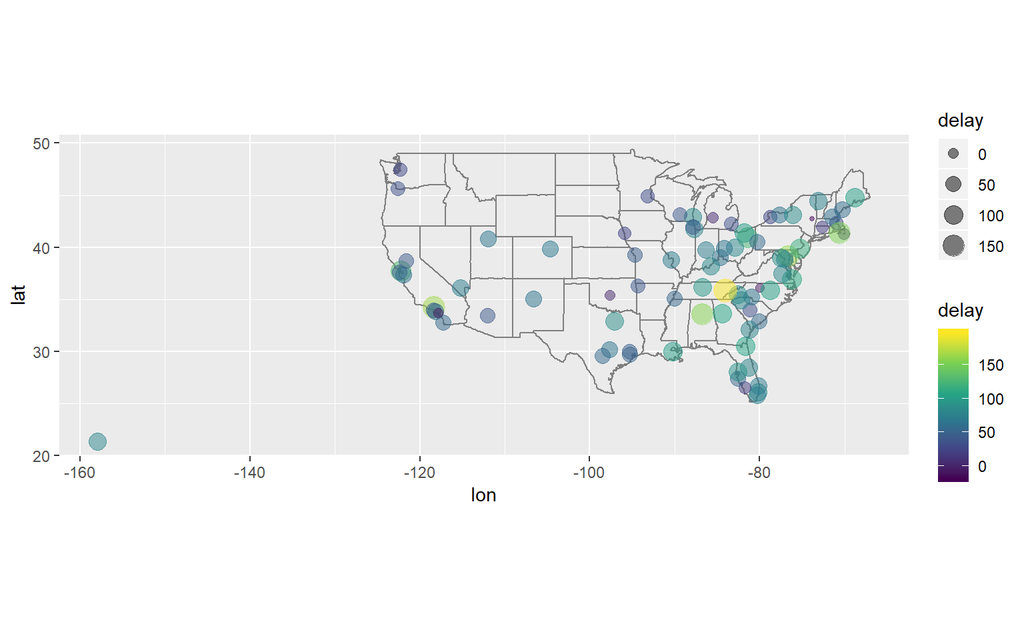

```r
flights %>%
  filter(year == 2013, month == 6, day == 13) %>%
  group_by(dest) %>%
  summarise(delay = mean(arr_delay, na.rm = TRUE)) %>%
  inner_join(airports, by = c("dest" = "faa")) %>%
  ggplot(aes(y = lat, x = lon, size = delay, colour = delay)) +
  borders("state") +
  geom_point(alpha = 1/2) +
  coord_quickmap() +
  scale_colour_viridis_c()
```

태풍이 없는 다음 달에는

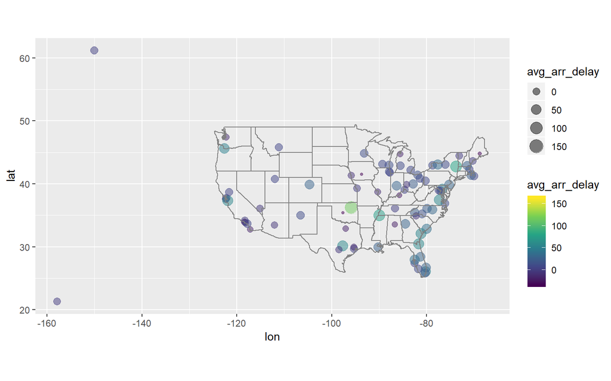

```r
flights %>%
  filter(year == 2013, month == 7, day == 13) %>%
  group_by(dest) %>%
  summarise(avg_arr_delay = mean(arr_delay, na.rm = TRUE)) %>%
  left_join(airports, by = c("dest" = "faa")) %>%
  ggplot(aes(lon, lat, size = avg_arr_delay, color = avg_arr_delay)) +
  geom_point(alpha = 1/2) +
  scale_color_viridis_c() +
  borders("state") +
  coord_quickmap()
```

### 2.10.1 Other Implementations

dplyr SQL

inner_join(x, y, by = “z”) SELECT * FROM x INNER JOIN y USING (z) left_join(x, y, by = “z”) SELECT * FROM x LEFT OUTER JOIN y USING (z) right_join(x, y, by = “z”) SELECT * FROM x RIGHT OUTER JOIN y USING (z) full_join(x, y, by = “z”) SELECT * FROM x FULL OUTER JOIN y USING (z)

## 2.11 Filtering Joins

mutating join과 같은 방식으록 관측치를 매칭시키지만, 변수가 아니라 관측치에 영향을 준다.

- `semi_join(x, y)` y에 매칭되는 모든 x 관측치를 유지한다.
- `anti_join(x, y)` y에 매칭되는 모든 x 관측치를 제거한다.

Semi_join은 기존의 행에 매칭되는 정제된 요약 테이블에 유용

```r
top_dest <- flights %>%
  count(dest, sort = TRUE) %>%
  head(10)
top_dest
```

```
## # A tibble: 10 x 2
##    dest      n
##    <chr> <int>
##  1 ORD   17283
##  2 ATL   17215
##  3 LAX   16174
##  4 BOS   15508
##  5 MCO   14082
##  6 CLT   14064
##  7 SFO   13331
##  8 FLL   12055
##  9 MIA   11728
## 10 DCA    9705
```

이 목적지들을 향하는 항공편들을 알고싶을 때 필터링 할 수 있다.

```r
flights %>%
  filter(dest %in% top_dest$dest)
```

```
## # A tibble: 141,145 x 19
##     year month   day dep_time sched_dep_time dep_delay arr_time
##    <int> <int> <int>    <int>          <int>     <dbl>    <int>
##  1  2013     1     1      542            540         2      923
##  2  2013     1     1      554            600        -6      812
##  3  2013     1     1      554            558        -4      740
##  4  2013     1     1      555            600        -5      913
##  5  2013     1     1      557            600        -3      838
##  6  2013     1     1      558            600        -2      753
##  7  2013     1     1      558            600        -2      924
##  8  2013     1     1      558            600        -2      923
##  9  2013     1     1      559            559         0      702
## 10  2013     1     1      600            600         0      851
## # ... with 141,135 more rows, and 12 more variables: sched_arr_time <int>,
## #   arr_delay <dbl>, carrier <chr>, flight <int>, tailnum <chr>,
## #   origin <chr>, dest <chr>, air_time <dbl>, distance <dbl>, hour <dbl>,
## #   minute <dbl>, time_hour <dttm>
```

하지만 이 방법은 다수의 변수로 확장하기에는 어렵다. 예를 들어, 가장 높은 평균 딜레이를 가지는 10일을 알고 있다고 생각해보자. flights에서 year, month, day를 사용하여 어떻게 필터링 코드를 작성할 것인가?

```r
flights %>%
  semi_join(top_dest)
```

```
## # A tibble: 141,145 x 19
##     year month   day dep_time sched_dep_time dep_delay arr_time
##    <int> <int> <int>    <int>          <int>     <dbl>    <int>
##  1  2013     1     1      542            540         2      923
##  2  2013     1     1      554            600        -6      812
##  3  2013     1     1      554            558        -4      740
##  4  2013     1     1      555            600        -5      913
##  5  2013     1     1      557            600        -3      838
##  6  2013     1     1      558            600        -2      753
##  7  2013     1     1      558            600        -2      924
##  8  2013     1     1      558            600        -2      923
##  9  2013     1     1      559            559         0      702
## 10  2013     1     1      600            600         0      851
## # ... with 141,135 more rows, and 12 more variables: sched_arr_time <int>,
## #   arr_delay <dbl>, carrier <chr>, flight <int>, tailnum <chr>,
## #   origin <chr>, dest <chr>, air_time <dbl>, distance <dbl>, hour <dbl>,
## #   minute <dbl>, time_hour <dttm>
```

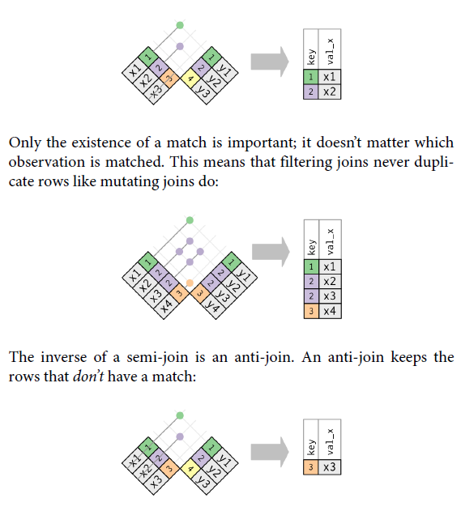

Anti-join은 매칭되지 않는 join을 진단할 때 유용하다. 예를 들어, flights와 planes를 연결시킬 때, 서로 연결되지 않는 것들이 있다.

```r
flights %>%
  anti_join(planes, by = "tailnum") %>%
  count(tailnum, sort = TRUE)
```

```
## # A tibble: 722 x 2
##    tailnum     n
##    <chr>   <int>
##  1 <NA>     2512
##  2 N725MQ    575
##  3 N722MQ    513
##  4 N723MQ    507
##  5 N713MQ    483
##  6 N735MQ    396
##  7 N0EGMQ    371
##  8 N534MQ    364
##  9 N542MQ    363
## 10 N531MQ    349
## # ... with 712 more rows
```

## 2.12 Exercises

1. What does it mean for a flight to have a missing tailnum? What do the tail numbers that don’t have a matching record in planes have in common? (Hint: one variable explains ~90% of the problems.)

NA가 많고, MQ항공사 비행기와 AA항공사 비행기가 많음을 알 수 있다.

```r
flights %>%
  anti_join(planes, by = "tailnum") %>%
  count(tailnum, sort = TRUE)
```

```
## # A tibble: 722 x 2
##    tailnum     n
##    <chr>   <int>
##  1 <NA>     2512
##  2 N725MQ    575
##  3 N722MQ    513
##  4 N723MQ    507
##  5 N713MQ    483
##  6 N735MQ    396
##  7 N0EGMQ    371
##  8 N534MQ    364
##  9 N542MQ    363
## 10 N531MQ    349
## # ... with 712 more rows
```

```r
flights %>%
  filter(is.na(tailnum)) %>%
  count(dep_time)
```

```
## # A tibble: 1 x 2
##   dep_time     n
##      <int> <int>
## 1       NA  2512
```

예상대로 비행기 결측치는 dep_time이 결측치(즉, 결항)과 일치한다.

planes의 description을 보면 AA와 MQ항공사는 fleet number로 보고한다고 적혀있다.

```r
flights %>%
  anti_join(planes, by = "tailnum") %>%
  count(carrier, sort = TRUE)
```

```
## # A tibble: 10 x 2
##    carrier     n
##    <chr>   <int>
##  1 MQ      25397
##  2 AA      22558
##  3 UA       1693
##  4 9E       1044
##  5 B6        830
##  6 US        699
##  7 FL        187
##  8 DL        110
##  9 F9         50
## 10 WN         38
```

2. Filter flights to only show flights with planes that have flown at least 100 flights.

```r
flight_100 <- flights %>%
  count(tailnum) %>%
  filter(n >= 100)

flights %>%
  semi_join(flight_100)
```

```
## # A tibble: 230,902 x 19
##     year month   day dep_time sched_dep_time dep_delay arr_time
##    <int> <int> <int>    <int>          <int>     <dbl>    <int>
##  1  2013     1     1      517            515         2      830
##  2  2013     1     1      533            529         4      850
##  3  2013     1     1      544            545        -1     1004
##  4  2013     1     1      554            558        -4      740
##  5  2013     1     1      555            600        -5      913
##  6  2013     1     1      557            600        -3      709
##  7  2013     1     1      557            600        -3      838
##  8  2013     1     1      558            600        -2      849
##  9  2013     1     1      558            600        -2      853
## 10  2013     1     1      558            600        -2      923
## # ... with 230,892 more rows, and 12 more variables: sched_arr_time <int>,
## #   arr_delay <dbl>, carrier <chr>, flight <int>, tailnum <chr>,
## #   origin <chr>, dest <chr>, air_time <dbl>, distance <dbl>, hour <dbl>,
## #   minute <dbl>, time_hour <dttm>
```

3. Combine fueleconomy::vehicles and fueleconomy::common to find only the records for the most common models.

```r
top10 <- fueleconomy::common %>%
  arrange(desc(n)) %>%
  head(1)
fueleconomy::vehicles %>%
  semi_join(top10, by = "model")
```

```
## # A tibble: 202 x 12
##       id make  model   year class  trans drive   cyl displ fuel    hwy   cty
##    <int> <chr> <chr>  <int> <chr>  <chr> <chr> <int> <dbl> <chr> <int> <int>
##  1 27343 Ford  F150 ~  1984 Stand~ Auto~ 2-Wh~     6   4.9 Regu~    15    13
##  2 27344 Ford  F150 ~  1984 Stand~ Auto~ 2-Wh~     6   4.9 Regu~    18    14
##  3 27345 Ford  F150 ~  1984 Stand~ Manu~ 2-Wh~     6   4.9 Regu~    19    15
##  4 27346 Ford  F150 ~  1984 Stand~ Manu~ 2-Wh~     6   4.9 Regu~    22    16
##  5 27347 Ford  F150 ~  1984 Stand~ Auto~ 2-Wh~     8   5   Regu~    12    11
##  6 27348 Ford  F150 ~  1984 Stand~ Auto~ 2-Wh~     8   5   Regu~    16    12
##  7 27349 Ford  F150 ~  1984 Stand~ Manu~ 2-Wh~     8   5   Regu~    15    12
##  8 27350 Ford  F150 ~  1984 Stand~ Manu~ 2-Wh~     8   5   Regu~    17    13
##  9 27351 Ford  F150 ~  1984 Stand~ Auto~ 2-Wh~     8   5.8 Regu~    12    11
## 10 27352 Ford  F150 ~  1984 Stand~ Manu~ 2-Wh~     8   5.8 Regu~    15    11
## # ... with 192 more rows
```

중요!! 4. Find the 48 hours (over the course of the whole year) that have the worst delays. Cross-reference it with the weather data. Can you see any patterns?

```r
flights_2day <- flights %>%
  group_by(year, month, day) %>%
  summarise(avg_dep_24 = mean(dep_delay, na.rm = TRUE),
            avg_arr_24 = mean(arr_delay, na.rm = TRUE)) %>%
  ungroup() %>%  # 이걸 하지 않으면 매달 1일마다 NA가 생긴다.
  mutate(avg_dep_48 = avg_dep_24 + lag(avg_dep_24),
         avg_arr_48 = avg_arr_24 + lag(avg_arr_24)) %>%
  unite(date, year, month, day, sep = "-") %>%
  mutate(date = parse_date(date, "%Y-%m-%d")) %>%
  gather(key = "type", value = "delay", 4:5) %>%
  mutate(type = factor(type, labels = c("Average departure delay",
                                        "Average arrival delay"))) %>% filter(!is.na(delay), date != "2013-12-31")

# 주의해야 할 점 : weather은 flights와 달리 마지막 날이 12월 30일이다.
weather_2day <- weather %>%
  group_by(year, month, day) %>%
  summarise(avg_wind_speed = mean(wind_speed, na.rm = TRUE),
            avg_wind_gust = mean(wind_gust, na.rm = TRUE),
            avg_percip = mean(precip, na.rm = TRUE),
            avg_visib = mean(visib, na.rm = TRUE),
            avg_temp = mean(temp, na.rm = TRUE),
            avg_humid = mean(humid, na.rm = TRUE)) %>%
  ungroup() %>%
  mutate(avg_wind_speed_48 = avg_wind_speed + lag(avg_wind_speed),
         avg_wind_gust_48 = avg_wind_gust + lag(avg_wind_gust),
         avg_percip_48 = avg_percip + lag(avg_percip),
         avg_visib_48 = avg_visib + lag(avg_visib),
         avg_temp_48 = avg_temp + lag(avg_temp),
         avg_humid_48 = avg_humid + lag(avg_humid)
         ) %>%
  unite(date, year, month, day, sep = "-") %>%
  mutate(date = parse_date(date, "%Y-%m-%d")) %>%
  filter(!is.na(avg_visib_48)) # 어차피 첫째날만 제거될 것임.

  #gather(key = "type", value = "delay", 8:13) %>%
  # mutate(type = factor(type, labels = c("Average windspeed",
  #                                       "Average windgust",
  #                                       "Average percip",
  #                                       "Average visibility",
  #                                       "Average temp",
  #                                       "Average humid"))) %>%
```

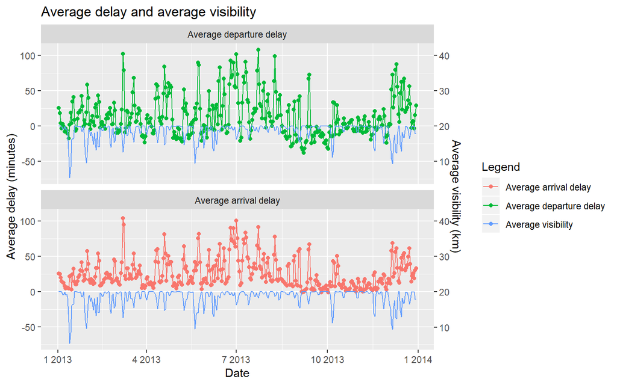

```r
ggplot(flights_2day) +
  geom_point(aes(date, delay, color = type)) +
  geom_line(aes(date, delay, color = type)) +
  # 날씨 정보를 좀 더 잘 보이게 하기 위해
  geom_line(data = weather_2day,
            aes(date, (avg_visib_48 - 20) * 5, color = 'Average visibility')) +
# 2차 축 조정. 위에서 취한 연산의 역
  scale_y_continuous(sec.axis = sec_axis(~. / 5 + 20 ,
                                         name = "Average visibility (km)")) +
  facet_wrap(~type, ncol = 1) +
  labs(x = "Date",
       y = "Average delay (minutes)",
       color = 'Legend',
       title = "Average delay and average visibility")
```

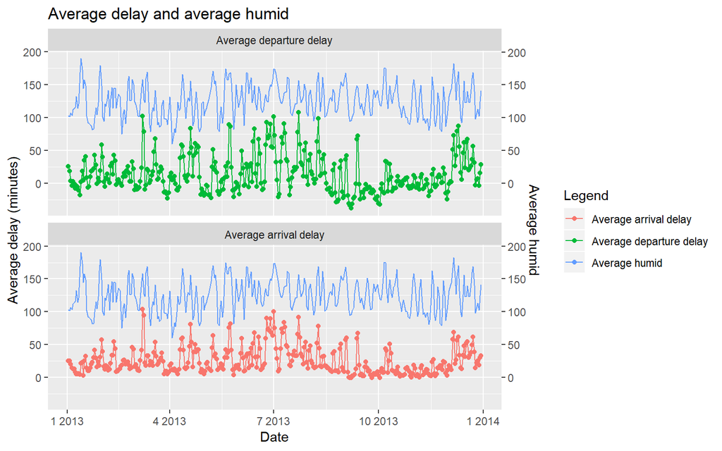

```r
ggplot(flights_2day) +
  geom_point(aes(date, delay, color = type)) +
  geom_line(aes(date, delay, color = type)) +
  geom_line(data = weather_2day,
            aes(date, avg_humid_48, color = "Average humid")) +
  scale_y_continuous(sec.axis = sec_axis(~., name = "Average humid")) +
  facet_wrap(~type, ncol = 1) +
   labs(x = "Date",
       y = "Average delay (minutes)",
       color = 'Legend',
       title = "Average delay and average humid")
```

습도는 2013년 10월을 제외하면 대체로 일치하는 것 같다.

5. What does anti_join(flights, airports, by = c(“dest” = “faa”)) tell you? What does anti_join(airports, flights, by = c(“faa” = “dest”)) tell you?

`anti_join(flights, airports, by = c("dest" = "faa"))` are flights that go to an airport that is not in FAA list of destinations, likely foreign airports.

`anti_join(airports, flights, by = c("faa" = "dest"))` are US airports that don’t have a flight in the data, meaning that there were no flights to that airport from New York in 2013.

6. You might expect that there’s an implicit relationship between plane and airline, because each plane is flown by a single airline. Confirm or reject this hypothesis using the tools you’ve learned in the preceding section.

```r
multi_carrier_planes <-
  flights %>%
  filter(!is.na(tailnum)) %>%
  count(tailnum, carrier) %>%
  count(tailnum) %>%
  filter(nn > 1)
multi_carrier_planes
```

```
## # A tibble: 17 x 2
##    tailnum    nn
##    <chr>   <int>
##  1 N146PQ      2
##  2 N153PQ      2
##  3 N176PQ      2
##  4 N181PQ      2
##  5 N197PQ      2
##  6 N200PQ      2
##  7 N228PQ      2
##  8 N232PQ      2
##  9 N933AT      2
## 10 N935AT      2
## 11 N977AT      2
## 12 N978AT      2
## 13 N979AT      2
## 14 N981AT      2
## 15 N989AT      2
## 16 N990AT      2
## 17 N994AT      2
```

To see which carriers these planes have been associated, filter the flights by tailnum in multi_carrier_planes, and extract the unique combinations of tailnum and carrier

```r
multi_carrier_planes <-
  flights %>%
  semi_join(multi_carrier_planes, by = "tailnum") %>%
  select(tailnum, carrier) %>%
  distinct() %>%
  arrange(tailnum)
multi_carrier_planes
```

```
## # A tibble: 34 x 2
##    tailnum carrier
##    <chr>   <chr>
##  1 N146PQ  9E
##  2 N146PQ  EV
##  3 N153PQ  9E
##  4 N153PQ  EV
##  5 N176PQ  9E
##  6 N176PQ  EV
##  7 N181PQ  9E
##  8 N181PQ  EV
##  9 N197PQ  9E
## 10 N197PQ  EV
## # ... with 24 more rows
```

항공사의 이름을 이해하기 쉽게하기 위해 tidy는 아니지만 다음과 같은 형태로 나타내었다.

```r
carrier_transfer_tbl <-
  multi_carrier_planes %>%
  group_by(tailnum) %>%
  mutate(
    carrier_num = seq_along(tailnum),
    carrier_num = paste0("carrier_", carrier_num)
  ) %>%
  left_join(airlines, by = "carrier") %>%
  select(-carrier) %>%
  spread(carrier_num, name)
carrier_transfer_tbl
```

```
## # A tibble: 17 x 3
## # Groups:   tailnum [17]
##    tailnum carrier_1                   carrier_2
##    <chr>   <chr>                       <chr>
##  1 N146PQ  Endeavor Air Inc.           ExpressJet Airlines Inc.
##  2 N153PQ  Endeavor Air Inc.           ExpressJet Airlines Inc.
##  3 N176PQ  Endeavor Air Inc.           ExpressJet Airlines Inc.
##  4 N181PQ  Endeavor Air Inc.           ExpressJet Airlines Inc.
##  5 N197PQ  Endeavor Air Inc.           ExpressJet Airlines Inc.
##  6 N200PQ  Endeavor Air Inc.           ExpressJet Airlines Inc.
##  7 N228PQ  Endeavor Air Inc.           ExpressJet Airlines Inc.
##  8 N232PQ  Endeavor Air Inc.           ExpressJet Airlines Inc.
##  9 N933AT  AirTran Airways Corporation Delta Air Lines Inc.
## 10 N935AT  AirTran Airways Corporation Delta Air Lines Inc.
## 11 N977AT  AirTran Airways Corporation Delta Air Lines Inc.
## 12 N978AT  AirTran Airways Corporation Delta Air Lines Inc.
## 13 N979AT  AirTran Airways Corporation Delta Air Lines Inc.
## 14 N981AT  AirTran Airways Corporation Delta Air Lines Inc.
## 15 N989AT  AirTran Airways Corporation Delta Air Lines Inc.
## 16 N990AT  AirTran Airways Corporation Delta Air Lines Inc.
## 17 N994AT  AirTran Airways Corporation Delta Air Lines Inc.
```

아니면

```r
flights %>%
  group_by(tailnum) %>%
  summarise(n = n_distinct(carrier)) %>% # n_distinct()와 length(unique())는 동일
  filter(n > 1)
```

```
## # A tibble: 18 x 2
##    tailnum     n
##    <chr>   <int>
##  1 N146PQ      2
##  2 N153PQ      2
##  3 N176PQ      2
##  4 N181PQ      2
##  5 N197PQ      2
##  6 N200PQ      2
##  7 N228PQ      2
##  8 N232PQ      2
##  9 N933AT      2
## 10 N935AT      2
## 11 N977AT      2
## 12 N978AT      2
## 13 N979AT      2
## 14 N981AT      2
## 15 N989AT      2
## 16 N990AT      2
## 17 N994AT      2
## 18 <NA>        7
```

## 2.13 Join Problems

실제로 데이터가 messy할 수 있으므로 부드럽게 join하기 위한 몇까지 방법이 있다.

```r
airports %>% count(alt, lon) %>%  filter(n > 1)
```

```
## # A tibble: 0 x 3
## # ... with 3 variables: alt <int>, lon <dbl>, n <int>
```

2. primary key가 missing인 것을 확인하라. 변수가 missing이면 관측치를 식별할 수 없다.
3. foreign key가 다른 테이블의 primary key와 매칭하는지 확인하라. 가장 좋은 방법은 `anti_join()`을 사용하는 것이다. 데이터 입력 오류 때문에 key가 매칭되지 않는 것은 흔한 오류이다. 이것을 고치는 것은 많은 작업이 필요하다.

missing keys를 가지고 있다면 outer join 대 inner join의 사용을 신중하게 고려하고, 주의깊에 매칭되지 않는 행을 제거하라.

join 전과 후 행의 수를 확인하는 것은 join이 부드럽게 잘 행해 졌는지 보장하기에 충분하지 않다는것을 인식해라. 만약 양쪽 테이블의 복제키에 inner join을 한다면, 복제된 행의 수와 동일하게 제거된 행의 수로써 얻는다.

## 2.14 Set Operations

하나의 복잡한 필터를 간단한 조각들로 나눌 때 집합 연산은 유용하다. 모든 집합 연산은 완전한 행과 함께 작동하며 모든 변수의 값을 비교한다. 이것은 x 와 y 입력이 같은 변수를 가지도록 기대하며, 관측치를 집합과 같이 다룬다.

`intersect(x, y)` : Return only observations in both x and y `union(x, y)` : Return unique observations in x and y `setdiff(x, y)` : Return observations in x, but not in y

```r
df1 <- tribble(
  ~x, ~y,
  1, 1,
  2, 1
)
df2 <- tribble(
  ~x, ~y,
  1, 1,
  1, 2
)

intersect(df1, df2)
```

```
## # A tibble: 1 x 2
##       x     y
##   <dbl> <dbl>
## 1     1     1
```

```r
union(df1, df2)
```

```
## # A tibble: 3 x 2
##       x     y
##   <dbl> <dbl>
## 1     1     2
## 2     2     1
## 3     1     1
```

```r
setdiff(df1, df2)
```

```
## # A tibble: 1 x 2
##       x     y
##   <dbl> <dbl>
## 1     2     1
```

```r
setdiff(df2, df1)
```

```
## # A tibble: 1 x 2
##       x     y
##   <dbl> <dbl>
## 1     1     2
```

# 3 Summary

- `complete()`, `fill()`
- mutating joins : primary key의 존재 유무는 `distinct`로 판단
- join을 두번 하면 suffix사용
- 바로 요약 그림을 그리지 말고 산점도를 먼저 그리자
- `semi-join()`을 사용하여 테이블을 필터링 할 수 있다.
- `anti-join()`을 사용하여 매칭되않는 관측치를 식별하자.
- cross-reference의 이해 : `scale_y_continuous(sec.axis = sec_axis(~., name = "Average humid"))`
- primary key를 확인하고 missing인지 확인하고 foreign key가 다른 테이블의 primary key와 매칭 되는지 anti_join()을 사용하라.
- 복잡한 필터를 간단한 조각들로 나누기 위해 집합 연산을 사용하자